# Case study Cyclistic Data

Joël Holla

2023-08-09

[figure not shown]

Cyclistic

This case study will follow the **ASK**, **PREPARE**, **PROCESS**, **ANALYZE**, **SHARE** and **ACT** steps for data analysis.

**Scenario**

I am working as a junior data analyst in the marketing analyst team at Cyclistic, a bike-share company in Chicago. The director of marketing believes the company’s future success depends on maximizing the number of annual memberships. Your team is asked to understand how casual riders and annual members use Cyclistic bikes differently. From these insights, your team will design a new marketing strategy to convert casual riders into annual members. Firstly, Cyclistic executives must approve your recommendations, so they must be backed up with compelling data insights and professional data visualizations.

**About the company**

In 2016, Cyclistic launched a successful bike-share offering. Since then, the program has grown to a fleet of 5,824 bicycles that are geotracked and locked into a network of 692 stations across Chicago. The bikes can be unlocked from one station and returned to any other station in the system at anytime.

One approach that helped make these things possible was the flexibility of its pricing plans: single-ride passes, full-day passes, and annual memberships. Customers who purchased single-ride or full-day passes are referred to as casual riders. Customers who purchased annual memberships are Cyclistic members.

Cyclistic’s finance analysts have concluded that annual members are much more profitable than casual riders. Although the pricing flexibility helps Cyclistic attract more customers, the marketing director believes that maximizing the number of annual members will be key to future growth. Rather than creating a marketing campaign that targets all-new customers, the marketing director believes there is a very good chance to convert casual riders into members.

**Goal of this case study**

How do annual members and casual riders use Cyclistic bikes differently?

Deliverables upon the completion of this project:

1. A clear statement of the business task
2. A description of all data sources used
3. Documentation of any cleaning or manipulation of data
4. A summary of your analysis
5. Supporting visualizations and key findings
6. Your top recommendations based on your analysis

**Ask**

Business task: The main goal of this case study is to maximize the number of annual memberships, through the analysis of trends and similarities between casual riders and annual members, to identify potential casual riders that would be interested in subscribing for annual membership

Stakeholders:

1. Director of Marketing
2. Marketing analytics team
3. Cyclistic executive team

**Prepare**

Data source: [Cyclistic data](https://divvy-tripdata.s3.amazonaws.com/index.html)

Cyclistic is a fictional company so we will be using the data made available by Motivate International Inc, under the Divvy bicycle sharing services [license](https://ride.divvybikes.com/data-license-agreement), from the months of July 2022 - June 2023

Investigated data using the ROCCC method:

**Reliable**: The dataset is unbiased and reliable.

**Original**: Original public internal data source

**Comprehensive**: The dataset has more than 5 million complete data entries.

**Current**: The dataset is updated monthly and includes the last 12 months

**Cited**: The data has not been cited

Key tasks:

1. The data has been stored and copied to the computer
2. Downloaded the data for the periods between July 2022 - June 2023
3. The dataset is organized into 12 separate csv files (comma-separated values) which includes 13 columns and over 5 million rows.

**Process**

##Tools used for processing data:

Due to the large amount of raw data included in the datasets, I chose to use the programming language R using R Studio Desktop, this was the best choice that R is extremely versatile with large datasets and also make it easier to reproduce the results.

Installed and loaded all the necessary packages and libraries to run and clean all the data. Uploaded all the csv files into individual dataframes using the read.csv() function from the readr library.

Install required packages tidyverse for data import and wrangling lubridate for date functions ggplot for visualization

**Cleaning and processing:**

**Load Libraries**

```r
library(tidyverse) #helps wrangle data
library(janitor)
library(lubridate) #helps wangle data attributes
library(hms) #helps to calculate the time
```

#===================== # STEP 1: COLLECT DATA #=====================

Import data into R Studio

```r
july_22 <- read.csv("~/Capstone Project Case Study 1/202207-divvy-tripdata.csv")
august_22 <- read.csv("~/Capstone Project Case Study 1/202208-divvy-tripdata.csv")
september_22 <- read.csv("~/Capstone Project Case Study 1/202209-divvy-publictripdata.csv")
october_22 <- read.csv("~/Capstone Project Case Study 1/202210-divvy-tripdata.csv")
november_22 <- read.csv("~/Capstone Project Case Study 1/202211-divvy-tripdata.csv")
december_22 <- read.csv("~/Capstone Project Case Study 1/202212-divvy-tripdata.csv")
january_23 <- read.csv("~/Capstone Project Case Study 1/202301-divvy-tripdata.csv")
february_23 <- read.csv("~/Capstone Project Case Study 1/202302-divvy-tripdata.csv")
march_23 <- read.csv("~/Capstone Project Case Study 1/202303-divvy-tripdata.csv")
april_23 <- read.csv("~/Capstone Project Case Study 1/202304-divvy-tripdata.csv")
may_23 <- read.csv("~/Capstone Project Case Study 1/202305-divvy-tripdata.csv")
june_23 <- read.csv("~/Capstone Project Case Study 1/202306-divvy-tripdata.csv")
```

#==================================================== # STEP 2: WRANGLE DATA AND COMBINE INTO A SINGLE FILE #====================================================

Combined the data using the rbind to bind the rows because the dataframes all used the same columns

```r
combined_data <- rbind(july_22, august_22, september_22, october_22, november_22, december_22, january_23, february_23, march_23, april_23, may_23, june_23)
```

Inspecting the combined dataframe using the ‘colnames’, ‘dim’, ‘head’, ‘str’, ‘summary’

```r
colnames(combined_data)
```

```
##  [1] "ride_id"            "rideable_type"      "started_at"
##  [4] "ended_at"           "start_station_name" "start_station_id"
##  [7] "end_station_name"   "end_station_id"     "start_lat"
## [10] "start_lng"          "end_lat"            "end_lng"
## [13] "member_casual"
```

Checking to see if any duplicates from the dataframe

```r
n_distinct(combined_data$ride_id) #Count distinct ride_id, it should be the same number as rows.
```

```
## [1] 5779444
```

```r
nrow(combined_data)
```

```
## [1] 5779444
```

```r
head(combined_data)
```

```
##            ride_id rideable_type          started_at            ended_at
## 1 954144C2F67B1932  classic_bike 2022-07-05 08:12:47 2022-07-05 08:24:32
## 2 292E027607D218B6  classic_bike 2022-07-26 12:53:38 2022-07-26 12:55:31
## 3 57765852588AD6E0  classic_bike 2022-07-03 13:58:49 2022-07-03 14:06:32
## 4 B5B6BE44314590E6  classic_bike 2022-07-31 17:44:21 2022-07-31 18:42:50
## 5 A4C331F2A00E79E0  classic_bike 2022-07-13 19:49:06 2022-07-13 20:15:24
## 6 579D73BE2ED880B3 electric_bike 2022-07-01 17:04:35 2022-07-01 17:13:18
##            start_station_name start_station_id               end_station_name
## 1  Ashland Ave & Blackhawk St            13224       Kingsbury St & Kinzie St
## 2  Buckingham Fountain (Temp)            15541          Michigan Ave & 8th St
## 3  Buckingham Fountain (Temp)            15541          Michigan Ave & 8th St
## 4  Buckingham Fountain (Temp)            15541         Woodlawn Ave & 55th St
## 5      Wabash Ave & Grand Ave     TA1307000117 Sheffield Ave & Wellington Ave
## 6 Desplaines St & Randolph St            15535      Clinton St & Roosevelt Rd
##   end_station_id start_lat start_lng  end_lat   end_lng member_casual
## 1   KA1503000043  41.90707 -87.66725 41.88918 -87.63851        member
## 2            623  41.86962 -87.62398 41.87277 -87.62398        casual
## 3            623  41.86962 -87.62398 41.87277 -87.62398        casual
## 4   TA1307000164  41.86962 -87.62398 41.79526 -87.59647        casual
## 5   TA1307000052  41.89147 -87.62676 41.93625 -87.65266        member
## 6         WL-008  41.88461 -87.64456 41.86712 -87.64109        member
```

```r
str(combined_data)
```

```
## 'data.frame':    5779444 obs. of  13 variables:
##  $ ride_id           : chr  "954144C2F67B1932" "292E027607D218B6" "57765852588AD6E0" "B5B6BE44314590E6" ...
##  $ rideable_type     : chr  "classic_bike" "classic_bike" "classic_bike" "classic_bike" ...
##  $ started_at        : chr  "2022-07-05 08:12:47" "2022-07-26 12:53:38" "2022-07-03 13:58:49" "2022-07-31 17:44:21" ...
##  $ ended_at          : chr  "2022-07-05 08:24:32" "2022-07-26 12:55:31" "2022-07-03 14:06:32" "2022-07-31 18:42:50" ...
##  $ start_station_name: chr  "Ashland Ave & Blackhawk St" "Buckingham Fountain (Temp)" "Buckingham Fountain (Temp)" "Buckingham Fountain (Temp)" ...
##  $ start_station_id  : chr  "13224" "15541" "15541" "15541" ...
##  $ end_station_name  : chr  "Kingsbury St & Kinzie St" "Michigan Ave & 8th St" "Michigan Ave & 8th St" "Woodlawn Ave & 55th St" ...
##  $ end_station_id    : chr  "KA1503000043" "623" "623" "TA1307000164" ...
##  $ start_lat         : num  41.9 41.9 41.9 41.9 41.9 ...
##  $ start_lng         : num  -87.7 -87.6 -87.6 -87.6 -87.6 ...
##  $ end_lat           : num  41.9 41.9 41.9 41.8 41.9 ...
##  $ end_lng           : num  -87.6 -87.6 -87.6 -87.6 -87.7 ...
##  $ member_casual     : chr  "member" "casual" "casual" "casual" ...
```

```r
summary(combined_data)
```

```
##    ride_id          rideable_type       started_at          ended_at
##  Length:5779444     Length:5779444     Length:5779444     Length:5779444
##  Class :character   Class :character   Class :character   Class :character
##  Mode  :character   Mode  :character   Mode  :character   Mode  :character
##
##
##
##
##  start_station_name start_station_id   end_station_name   end_station_id
##  Length:5779444     Length:5779444     Length:5779444     Length:5779444
##  Class :character   Class :character   Class :character   Class :character
##  Mode  :character   Mode  :character   Mode  :character   Mode  :character
##
##
##
##
##    start_lat       start_lng         end_lat         end_lng
##  Min.   :41.64   Min.   :-87.87   Min.   : 0.00   Min.   :-88.16
##  1st Qu.:41.88   1st Qu.:-87.66   1st Qu.:41.88   1st Qu.:-87.66
##  Median :41.90   Median :-87.64   Median :41.90   Median :-87.64
##  Mean   :41.90   Mean   :-87.65   Mean   :41.90   Mean   :-87.65
##  3rd Qu.:41.93   3rd Qu.:-87.63   3rd Qu.:41.93   3rd Qu.:-87.63
##  Max.   :42.07   Max.   :-87.52   Max.   :42.37   Max.   :  0.00
##                                   NA's   :5795    NA's   :5795
##  member_casual
##  Length:5779444
##  Class :character
##  Mode  :character
##
##
##
##
```

#====================================================== # STEP 3: CLEAN UP AND ADD DATA TO PREPARE FOR ANALYSIS #======================================================

1. Calculated and adding into a new column the ride_length

```r
combined_data$ride_length <- as_hms(difftime(combined_data$ended_at, combined_data$started_at))
```

2. Created the column of day_of_week to assign a numeric value of 1 through 7 to days of the week using the wday().

```r
combined_data$day_of_week <- wday(combined_data$started_at)
```

3. Removed empty rows

```r
combined_data <- janitor::remove_empty(combined_data,which = c("cols")) #removes empty columns
combined_data<- janitor::remove_empty(combined_data,which = c("rows")) #removes empty rows
```

4. Created a new dataframe to exclude the rows with negative time in ride_length. (Negative entries occurred when bikes were taken out of docks and checked for quality by Cyclistic)

```r
sum(combined_data$ride_length < 0, na.rm=TRUE)#Counts number of rows < 0 in 'ride_length')
```

```
## [1] 107
```

```r
combined_data_v2 <- combined_data[!(combined_data$ride_length<0),]
sum(combined_data_v2$ride_length < 0, na.rm=TRUE) #Counts number of rows < 0 in 'ride_length')
```

```
## [1] 0
```

5. Changed the numeric data of day_of_week to a string.

```r
combined_data_v2 <- combined_data_v2 %>%
  mutate(day_of_week=recode(day_of_week,
                            "1" = "Sunday",
                            "2" = "Monday",
                            "3" = "Tuesday",
                            "4" = "Wednesday",
                            "5" = "Thursday",
                            "6" = "Friday",
                            "7" = "Saturday"))
```

**Analyze**

#===================================== # STEP 4: CONDUCT DESCRIPTIVE ANALYSIS #=====================================

Descriptive analysis on ride_length (all figures in seconds)

```r
as_hms(mean(combined_data_v2$ride_length)) #straight average (total ride length / rides)
```

```
## 00:18:20.602156
```

```r
as_hms(median(combined_data_v2$ride_length)) #midpoint number in the ascending array of ride lengths
```

```
## 00:09:42
```

```r
as_hms(max(combined_data_v2$ride_length)) #longest ride
```

```
## 689:47:15
```

```r
as_hms(min(combined_data_v2$ride_length)) #shortest ride
```

```
## 00:00:00
```

Descriptive analysis on ‘ride_length’ by user type comparing casual and member users:

```r
aggregate(combined_data_v2$ride_length ~ combined_data_v2$member_casual, FUN = mean)
```

```
##   combined_data_v2$member_casual combined_data_v2$ride_length
## 1                         casual               1663.8809 secs
## 2                         member                743.0179 secs
```

```r
aggregate(combined_data_v2$ride_length ~ combined_data_v2$member_casual, FUN = median)
```

```
##   combined_data_v2$member_casual combined_data_v2$ride_length
## 1                         casual                          720
## 2                         member                          513
```

```r
aggregate(combined_data_v2$ride_length ~ combined_data_v2$member_casual, FUN = max)
```

```
##   combined_data_v2$member_casual combined_data_v2$ride_length
## 1                         casual                 2483235 secs
## 2                         member                   90031 secs
```

```r
aggregate(combined_data_v2$ride_length ~ combined_data_v2$member_casual, FUN = min)
```

```
##   combined_data_v2$member_casual combined_data_v2$ride_length
## 1                         casual                       0 secs
## 2                         member                       0 secs
```

See the average ride time by each day for members vs casual users

1. Reordered the column day_of_week

```r
combined_data_v2$day_of_week <- ordered(combined_data_v2$day_of_week, levels=c("Sunday", "Monday", "Tuesday", "Wednesday", "Thursday", "Friday", "Saturday"))
```

2. Ran the average ride time by each day for members vs casual users

```r
aggregate(combined_data_v2$ride_length ~ combined_data_v2$member_casual + combined_data_v2$day_of_week, FUN = mean)
```

```
##    combined_data_v2$member_casual combined_data_v2$day_of_week
## 1                          casual                       Sunday
## 2                          member                       Sunday
## 3                          casual                       Monday
## 4                          member                       Monday
## 5                          casual                      Tuesday
## 6                          member                      Tuesday
## 7                          casual                    Wednesday
## 8                          member                    Wednesday
## 9                          casual                     Thursday
## 10                         member                     Thursday
## 11                         casual                       Friday
## 12                         member                       Friday
## 13                         casual                     Saturday
## 14                         member                     Saturday
##    combined_data_v2$ride_length
## 1                1967.2067 secs
## 2                 820.3259 secs
## 3                1630.5872 secs
## 4                 706.0557 secs
## 5                1452.1944 secs
## 6                 710.2097 secs
## 7                1395.3616 secs
## 8                 709.5315 secs
## 9                1395.7291 secs
## 10                713.4024 secs
## 11               1614.9352 secs
## 12                738.5969 secs
## 13               1941.4777 secs
## 14                837.4757 secs
```

```r
combined_data_v2 %>%
  group_by(months = month.name[month(started_at)], member_casual) %>%
  summarize(row_count = n()) %>%
  arrange(match(months,month.name))
```

```
## # A tibble: 24 × 3
## # Groups:   months [12]
##    months   member_casual row_count
##    <chr>    <chr>             <int>
##  1 January  casual            40008
##  2 January  member           150293
##  3 February casual            43016
##  4 February member           147428
##  5 March    casual            62201
##  6 March    member           196477
##  7 April    casual           147284
##  8 April    member           279302
##  9 May      casual           234178
## 10 May      member           370639
## # ℹ 14 more rows
```

**Share**

#Analyze rider data by type and weekday

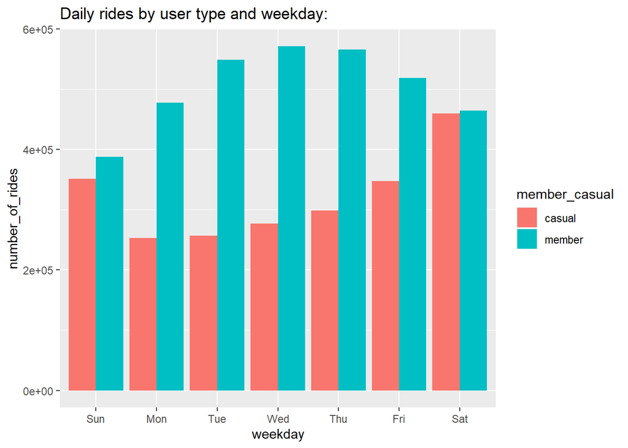

```r
combined_data_v2 %>%
  mutate(weekday = wday(started_at, label = TRUE)) %>%
  group_by(member_casual, weekday) %>%
  summarise(number_of_rides = n()
            ,average_duration = mean(ride_length)) %>%
  arrange(member_casual, weekday)  %>%
  ggplot(aes(x = weekday, y = number_of_rides, fill = member_casual)) +
  geom_col(position = "dodge")+
  ggtitle("Daily rides by user type and weekday:")
```

```
## Defaulting to continuous.
```

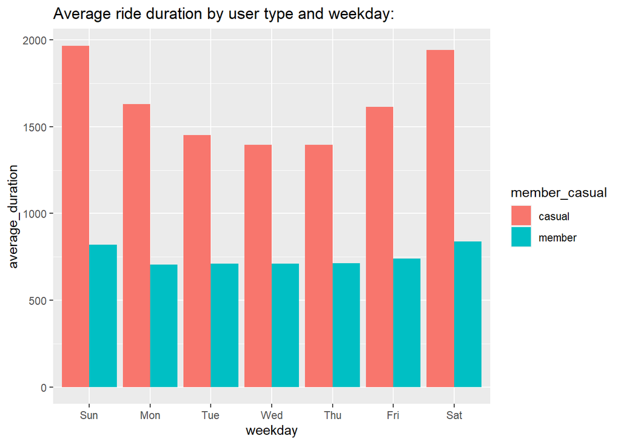

```r
combined_data_v2%>%
  mutate(weekday = wday(started_at, label = TRUE)) %>%
  group_by(member_casual, weekday) %>%
  summarise(number_of_rides = n()
            ,average_duration = mean(ride_length)) %>%
  arrange(member_casual, weekday)  %>%
  ggplot(aes(x = weekday, y = average_duration, fill = member_casual)) +
  geom_col(position = "dodge")+
  ggtitle("Average ride duration by user type and weekday:")
```

**Conclusion**

**Act**

Recommendation for the stakeholders.

1. *Seasonal marketing* campaigns during the peak months of June, July and August, targeted toward the casual riders, demonstrating the cost-effectiveness of an all-year round membership.
2. *Weekend promotion:* Offer benefits on weekends, such as exclusive access to certain events and spots, and coupons at restaurants. Highlight the flexibility and convenience of Cyclistic bikes for weekend adventures and leisure activities.